# Análise IMDB

Beatriz Milz e William Amorim

10 de fevereiro de 2021

O objetivo desta análise é responder a pergunta *Quem é a melhor pessoa para dirigir filmes de comédia, produzido nos Estados Unidos?*

## Melhor é ser lucrativo?

Como muitos fatores podem influenciar a receita de um filme, consequentemente o seu lucro, a variabilidade sobre essas variáveis pode ser muito grande. Assim, dentre as pessoas que mais dirigiram filmes de comédia, vamos olhar para aqueles que, em média, lucram mais.

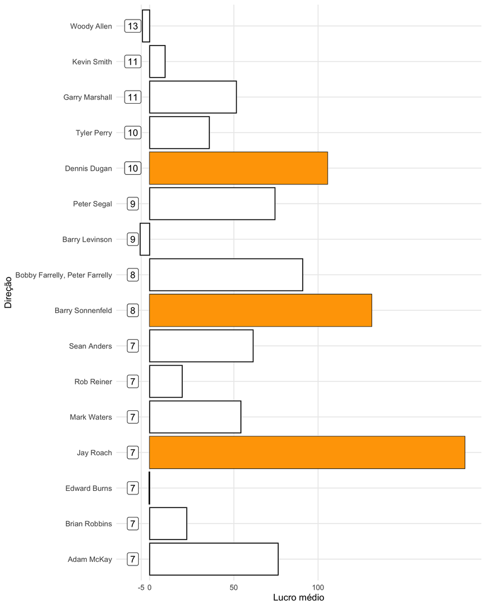

O diretor Jay Roach parece ser uma aposta mais segura, pois tem um lucro médio de 187 milhões de dólares com 7 filmes marcados como comédia na base.

Jay Roach é o diretor da série *Austin Powers* e *Entrando numa fria*.

| Filme | Orçamento | Receita | Lucro | Nota |
| --- | --- | --- | --- | --- |
| Austin Powers in Goldmember | $63.000.000 | $296.938.801 | $233.938.801 | 6.2 |
| Austin Powers: International Man of Mystery | $16.500.000 | $67.683.989 | $51.183.989 | 7.0 |
| Austin Powers: The Spy Who Shagged Me | $33.000.000 | $312.016.928 | $279.016.928 | 6.6 |
| Dinner for Schmucks | $69.000.000 | $86.855.739 | $17.855.739 | 5.9 |
| Meet the Fockers | $80.000.000 | $522.657.936 | $442.657.936 | 6.3 |
| Meet the Parents | $55.000.000 | $330.444.045 | $275.444.045 | 7.0 |
| The Campaign | $95.000.000 | $104.907.746 | $9.907.746 | 6.1 |

## Melhor é ser bem avaliado?

Embora subjetiva, a nota IMDB é uma boa estimativa da opinião pública sobre um filme, pois é uma média de diversos olhares diferentes. Pelo menos um filme aclamado é um bom indício de que a direção sabe conduzir um filme de sucesso.

A tabela a seguir mostra que o filme marcado como comédia com maior nota na nossa base é dirigido por Robert Zemeckis.

| Filme | Direção | Nota IMDB |
| --- | --- | --- |
| Back to the Future | Robert Zemeckis | 8.5 |
| It’s Such a Beautiful Day | Don Hertzfeldt | 8.3 |
| Toy Story 3 | Lee Unkrich | 8.3 |
| Toy Story | John Lasseter | 8.3 |
| Up | Pete Docter, Bob Peterson | 8.2 |
| The Truman Show | Peter Weir | 8.1 |
| Dead Poets Society | Peter Weir | 8.1 |
| Inside Out | Pete Docter, Ronnie Del Carmen | 8.1 |
| Ratatouille | Brad Bird, Jan Pinkava | 8.0 |
| Deadpool | Tim Miller | 8.0 |
| Zootopia | Byron Howard, Rich Moore | 8.0 |
| Aladdin | Ron Clements, John Musker | 8.0 |
| Guardians of the Galaxy | James Gunn | 8.0 |
| Groundhog Day | Harold Ramis | 8.0 |
| Monsters, Inc. | Pete Docter, David Silverman | 8.0 |

Vamos olhar mais atentamente os filmes dirigidos por Robert Zemeckis. Além de Forest Gump, ele é o diretor da consagrada trilogia *De Volta Para o Futuro*.

| Filme | Orçamento | Receita | Lucro | Nota |
| --- | --- | --- | --- | --- |
| Forrest Gump | $55.000.000 | $678.229.452 | $623.229.452 | 8.8 |
| Back to the Future | $19.000.000 | $388.774.684 | $369.774.684 | 8.5 |
| Cast Away | $90.000.000 | $429.632.142 | $339.632.142 | 7.8 |
| Back to the Future Part II | $40.000.000 | $335.973.020 | $295.973.020 | 7.8 |
| Back to the Future Part III | $40.000.000 | $246.145.853 | $206.145.853 | 7.4 |
| Contact | $90.000.000 | $171.120.329 | $81.120.329 | 7.4 |
| The Walk | $35.000.000 | $61.181.942 | $26.181.942 | 7.3 |
| I Wanna Hold Your Hand | $2.700.000 | $1.944.682 | -$755.318 | 6.9 |
| Used Cars | $8.000.000 | $11.715.321 | $3.715.321 | 6.8 |
| A Christmas Carol | $200.000.000 | $325.286.646 | $125.286.646 | 6.8 |
| Death Becomes Her | $55.000.000 | $149.022.650 | $94.022.650 | 6.6 |
| What Lies Beneath | $100.000.000 | $291.420.351 | $191.420.351 | 6.6 |
| The Polar Express | $165.000.000 | $313.500.433 | $148.500.433 | 6.6 |

## Roach ou Zemeckis?

Comparando os dois diretores, percebemos que Robert Zemeckis se destaca na categoria nota IMDB. Ele já dirigiu grandes sucessos de bilheteria e crítica.

Pelos critérios analisados, indicamos Robert Zemeckis como o melhor diretor de comédia.

[output not shown]